# Monte Carlo Simulation of Bayesian Models

Ken Wood

2023-07-11

$y_i=\mu+\epsilon_i,\space \space \epsilon \stackrel{iid}{\sim}N(0,\sigma^2),\space i=1,..,n$

$\therefore \space y_i \stackrel{iid}{\sim}N(0,\sigma^2)$

**Likelihood:** $P(y|\theta) = \frac{P(y,\theta)}{P(\theta)}$, where $P(\theta)$ is the **prior** probability distribution of $\theta$.

**Posterior:** $P(\theta|y) = \frac{P(y,\theta)}{P(y)} = \frac{P(y,\theta)}{\int P(y,\theta) \space d\theta} = \frac{P(y|\theta)P(\theta)}{\int P(y|\theta)P(\theta) \space d\theta} = \frac{1}{K}P(y|\theta)P(\theta)$

where $K$ is a constant and independent of $\theta$.

#### Hierarchical Bayesian Model

1. $\space \space y_i \stackrel{iid}{\sim}N(0,\sigma^2)$
2. $\space \space \mu|\sigma^2 \sim N(\mu_0,\frac{\sigma_0^2}{\omega_0})$
3. $\space \space \sigma^2 \sim \Gamma^{-1}(\alpha_{\space0},\beta_{\space0})$

Let’s look at the $Gamma$ distribution:

```r
set.seed(32)
m=100
a=2
b=1/3
```

Get $m=100$ samples from the $Gamma$ distribution.

```r
theta=rgamma(n=m,shape=a,rate=b)
head(theta)
```

```
## [1] 4.553954 8.280642 1.515590 9.160268 3.507859 5.606974
```

```r
tail(theta)
```

```
## [1] 2.432403 7.148443 2.715706 2.763691 5.413677 5.865641
```

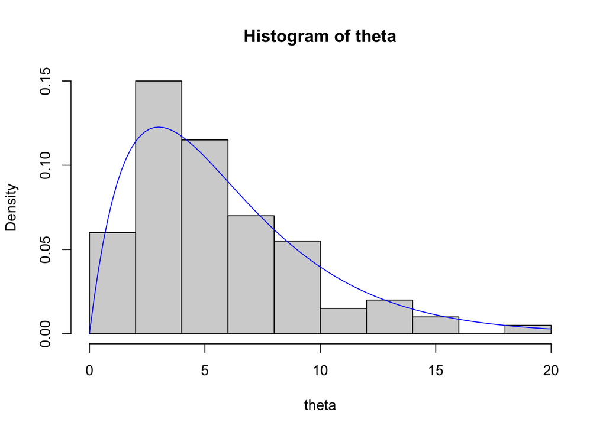

```r
hist(theta,freq=FALSE)
curve(dgamma(x,shape=a,rate=b), col='blue',add=TRUE)
```

Calculate mean of the simulated values for $\theta$:

```r
mean(theta)
```

```
## [1] 5.514068
```

```r
var(theta)
```

```
## [1] 12.56345
```

The mean and variance of a gamma distribution $\Gamma(a,b)$ is $\frac{a}{b}$ and $\frac{a}{b^2}$ respectively.

```r
a/b
```

```
## [1] 6
```

```r
a/b^2
```

```
## [1] 18
```

Looks like we need to get more samples for $\theta$.

```r
m=10000
theta=rgamma(n=m,shape=a,rate=b)
mean(theta)
```

```
## [1] 6.023273
```

```r
var(theta)
```

```
## [1] 18.04318
```

Let’s look at $P(\theta < 5)$

```r
ind=theta<5
head(ind)
```

```
## [1] FALSE FALSE  TRUE  TRUE FALSE FALSE
```

```r
mean(ind) # Probability that theta < 5
```

```
## [1] 0.497
```

Now, lets calculate $P(\theta<5)$ using the `pgamma` function.

```r
pgamma(q=5,shape=a,rate=b)
```

```
## [1] 0.4963317
```

Now, lets take a look at the 90th percentile of $\theta$:

```r
quantile(theta,probs=0.9)
```

```
##      90%
## 11.74338
```

Now, lets the 90th percentile using the `qgamma` function.

```r
qgamma(0.9,shape=a,rate=b)
```

```
## [1] 11.66916
```

Let’s calculate the standard error and confidence interval for $\theta$:

```r
std_error = sd(theta)/sqrt(m)
lower = mean(theta)-std_error
lower
```

```
## [1] 5.980796
```

```r
upper = mean(theta)+std_error
upper
```

```
## [1] 6.065751
```

Lets go back to $P(\theta<5)$ using the `pgamma` function.

```r
ind=theta<5
mean(ind) # Probability that theta < 5
```

```
## [1] 0.497
```

```r
pgamma(5,shape=a,rate=b)
```

```
## [1] 0.4963317
```

Our Monte Carlo estimate of the probability is within 0.01 of the true mean.

```r
std_error=sd(ind)/sqrt(m)
2*std_error
```

```
## [1] 0.01000032
```

Now, let’s simulate $\phi_i$ from $Beta(2,2)$, then we will simulate $y_i$ from $Binom(10,\phi_i)$

```r
m=1e5
y=numeric(m)
phi=numeric(m)
```

Now loop $i=1:m$ times to fill the $\phi_i$ and $y_i$ vectors using the `rbeta` and `rbinom` functions.

```r
# for (i in 1:m) {
#  phi[i]=rbeta(1,shape1=2,shape2=2)
#  y[i]=rbinom(n=1,size=10,prob=phi[i])
#}
```

Loops are not particularly efficient, let’s use vectorized code

```r
phi=rbeta(m,shape1=2,shape2=2)
y=rbinom(n=m,size=10,prob=phi)
```

```r
table(y)/m
```

```
## y
##       0       1       2       3       4       5       6       7       8       9
## 0.03908 0.06929 0.09475 0.11288 0.12243 0.12448 0.12011 0.11275 0.09604 0.07029
##      10
## 0.03790
```

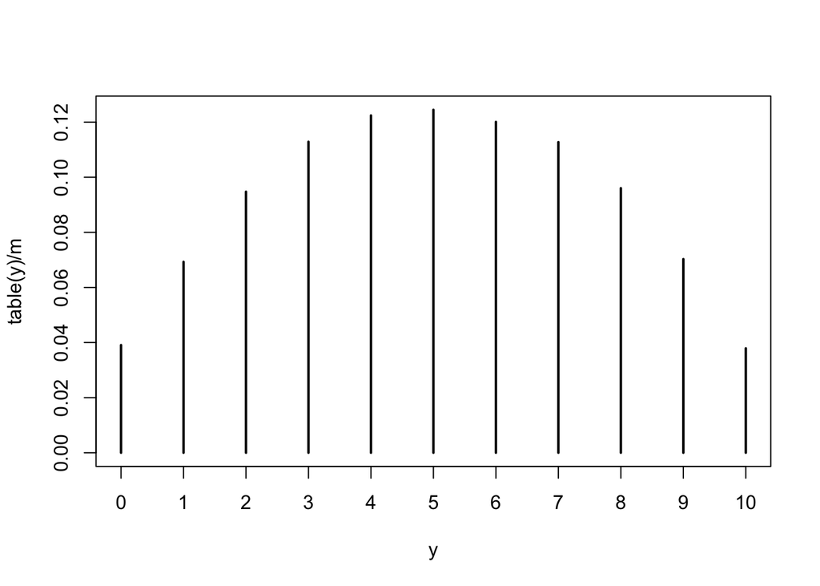

```r
plot(table(y)/m)
```

```r
mean(y)
```

```
## [1] 4.99939
```

**Problem 1:** Laura keeps a record of her loan applications and performs a Bayesian analysis of her success rate, $\theta$. Her analysis yields a $Beta(5,3)$ posterior distribution for $\theta$.

The posterior mean for $\theta = 5/(5+3) = 0.625$. However, Laura likes to think in terms of odds of succeeding, defined as $\frac{\theta}{1-\theta}$, the probability of success divided by the probability of failure.

Simulate a large number of samples for the posterior distribution of $\theta$ and use these samples to approximate the posterior mean for Laura’s odds of success, namely $E(\frac{\theta}{1-\theta})$.

```r
m=1e5
a=5
b=3
theta=rbeta(m,shape1 = a,shape2 = b)
mean(theta/(1-theta))
```

```
## [1] 2.506003
```

**Problem 2:** Laura also wants to know the posterior probability that her odds for success on loan applications is > 1 (in other words, better that 50:50 odds).

```r
ind=(theta/(1-theta))>1
mean(ind)
```

```
## [1] 0.77502
```

```r
# ind=(theta/(1-theta))<1
# 1-mean(ind)
```

**Problem 3:** Use a (large) Monte Carlo sample to approximate the 0.3 quantile of the standard Normal distribution, $N(0,1)$, the number such that the probability of being less than 0.3. Use the `quantile` function in R. We can also check our answer using the `qnorm` function.

```r
m=1e6
theta=rnorm(m,0,1)
quantile(theta,probs=0.3)
```

```
##        30%
## -0.5248922
```

```r
qnorm(0.3,0,1)
```

```
## [1] -0.5244005
```

To measure how accurate our Monte Carlo approximations are, we can use the Central Limit Theorem (CLT). If the number of samples drawn, $m$, is large, then the Monte Carlo sample mean $\bar{\theta^*}$ used to estimate $E(\theta)$ approximately follows a normal distribution with mean $E(\theta)$ and variance $Var(\theta)/m$. If we substitute the sample variance for $Var(\theta)$, we can get a rough estimate of our Monte Carlo standard error (or standard deviation).

Suppose we have 100 samples from our posterior distribution $\theta_i^*$, and that the sample variance of these draws is 5.2. A rough estimate of our Monte Carlo standard error would then be $\sqrt{5.2/100} \approx 0.228$. So our estimate, $\theta^*$, is probably within about $0.456$ (two standard errors) of the true $E(\theta)$.

**Problem 4:** What does the standard error of our Monte Carlo estimate become if we increase our sample size to 5000? Assume that the variance of the sample draws is still 5.2.

```r
sqrt(5.2/5000)
```

```
## [1] 0.03224903
```